# microarray2

Seoyeon Oh

12/8/2021

## E-GEOD-64750

### Intensity values

Read in the microarray data and examine dimensionsionality of the intensity value matrix.

```r
id <- "E-GEOD-64750"
exonCELs <- list.celfiles("C:/Users/tobia/Downloads/Array2")
data.raw_2 <- read.celfiles(paste(rep("C:/Users/tobia/Downloads/Array2/",length(exonCELs)),exonCELs,sep=""))
```

```
## Reading in : C:/Users/tobia/Downloads/Array2/GSM1579245_jac013-430v2.CEL
## Reading in : C:/Users/tobia/Downloads/Array2/GSM1579246_jac021-430v2.CEL
## Reading in : C:/Users/tobia/Downloads/Array2/GSM1579247_jac044-430v2.CEL
## Reading in : C:/Users/tobia/Downloads/Array2/GSM1579248_jac045-430v2.CEL
## Reading in : C:/Users/tobia/Downloads/Array2/GSM1579249_jac046-430v2.CEL
## Reading in : C:/Users/tobia/Downloads/Array2/GSM1579250_jac007-430v2.CEL
## Reading in : C:/Users/tobia/Downloads/Array2/GSM1579251_jac008-430v2.CEL
## Reading in : C:/Users/tobia/Downloads/Array2/GSM1579252_jac036-430v2.CEL
## Reading in : C:/Users/tobia/Downloads/Array2/GSM1579253_jac047-430v2.CEL
## Reading in : C:/Users/tobia/Downloads/Array2/GSM1579254_jac014-430v2.CEL
## Reading in : C:/Users/tobia/Downloads/Array2/GSM1579255_jac024-430v2.CEL
## Reading in : C:/Users/tobia/Downloads/Array2/GSM1579256_jac025-430v2.CEL
## Reading in : C:/Users/tobia/Downloads/Array2/GSM1579257_jac011-430v2.CEL
## Reading in : C:/Users/tobia/Downloads/Array2/GSM1579258_jac012-430v2.CEL
## Reading in : C:/Users/tobia/Downloads/Array2/GSM1579259_jac037-430v2.CEL
## Reading in : C:/Users/tobia/Downloads/Array2/GSM1579260_jac048-430v2.CEL
```

```r
dim(exprs(data.raw_2))
```

```
## [1] 1004004      16
```

```r
head(exprs(data.raw_2))
```

```
##   GSM1579245_jac013-430v2.CEL GSM1579246_jac021-430v2.CEL
## 1                          62                         191
## 2                        5707                       16272
## 3                          69                         265
## 4                        5913                       16107
## 5                          57                         143
## 6                          54                         143
##   GSM1579247_jac044-430v2.CEL GSM1579248_jac045-430v2.CEL
## 1                         198                         134
## 2                        7485                        5697
## 3                         200                         144
## 4                        7664                        6184
## 5                         154                         121
## 6                         162                         128
##   GSM1579249_jac046-430v2.CEL GSM1579250_jac007-430v2.CEL
```

[output cut: 41 more lines]

### Annotation

Here we provide basic sample annotation, including the phenotype of interest and relevant other features (e.g. confounders). This dataset contains array data (A-AFFY-45) of different mice strains (BXD98, BXD97, BXD83, BXD73, BXD68, BXD67 ,BXD43, C57BL/6J, DBA/2J) infected with influenza virus H5N1.

```r
sdrf <- read.delim("C:/Users/tobia/Downloads/Array2/E-GEOD-64750.sdrf.txt")
print(sdrf[,c("Source.Name","Comment..Sample_source_name.","Array.Design.REF", "Characteristics..strain.", "Comment..Sample_description.")])
```

```
##     Source.Name                                Comment..Sample_source_name.
## 1  GSM1579281 1 Highly Pathogenic H5N1 Influenza A virus infected; 72 hours
## 2  GSM1579280 1 Highly Pathogenic H5N1 Influenza A virus infected; 72 hours
## 3  GSM1579279 1 Highly Pathogenic H5N1 Influenza A virus infected; 72 hours
## 4  GSM1579278 1 Highly Pathogenic H5N1 Influenza A virus infected; 72 hours
## 5  GSM1579277 1 Highly Pathogenic H5N1 Influenza A virus infected; 72 hours
## 6  GSM1579276 1 Highly Pathogenic H5N1 Influenza A virus infected; 72 hours
## 7  GSM1579275 1 Highly Pathogenic H5N1 Influenza A virus infected; 72 hours
## 8  GSM1579274 1 Highly Pathogenic H5N1 Influenza A virus infected; 72 hours
## 9  GSM1579273 1 Highly Pathogenic H5N1 Influenza A virus infected; 72 hours
## 10 GSM1579272 1 Highly Pathogenic H5N1 Influenza A virus infected; 72 hours
## 11 GSM1579271 1 Highly Pathogenic H5N1 Influenza A virus infected; 72 hours
## 12 GSM1579270 1 Highly Pathogenic H5N1 Influenza A virus infected; 72 hours
## 13 GSM1579269 1 Highly Pathogenic H5N1 Influenza A virus infected; 72 hours
## 14 GSM1579268 1 Highly Pathogenic H5N1 Influenza A virus infected; 72 hours
```

[output cut: 99 more lines]

### Which samples we are using, and not using:

We will be using samples involving susceptible and resistant mouse strain, DBA/2J (GSM1579245 - GSM1579253) and C57BL/6J (GSM1579254 - GSM1579260) respectively. Each strain was inoculated with H5N1 influenza A virus. We are not using the data from other strains (BXD98, BXD97, BXD83, BXD73, BXD68, BXD67, BXD43) which do not contain non-infected control samples.

```r
#load first lines of output from the object
#head(exprs(MouseExp_pheno2))
#pData(MouseExp_pheno2)  #source name, comment sample description, sample source name, sample title, characteristics, organism, term.source, accession number, sex ...
```

```r
filter <- colnames(data.raw_2)[data.raw_2@phenoData@data$index <= 16]
filter
```

```
##  [1] "GSM1579245_jac013-430v2.CEL" "GSM1579246_jac021-430v2.CEL"
##  [3] "GSM1579247_jac044-430v2.CEL" "GSM1579248_jac045-430v2.CEL"
##  [5] "GSM1579249_jac046-430v2.CEL" "GSM1579250_jac007-430v2.CEL"
##  [7] "GSM1579251_jac008-430v2.CEL" "GSM1579252_jac036-430v2.CEL"
##  [9] "GSM1579253_jac047-430v2.CEL" "GSM1579254_jac014-430v2.CEL"
## [11] "GSM1579255_jac024-430v2.CEL" "GSM1579256_jac025-430v2.CEL"
## [13] "GSM1579257_jac011-430v2.CEL" "GSM1579258_jac012-430v2.CEL"
## [15] "GSM1579259_jac037-430v2.CEL" "GSM1579260_jac048-430v2.CEL"
```

```r
filtered <- data.raw_2[,filter]
filtered
```

```
## ExpressionFeatureSet (storageMode: lockedEnvironment)
## assayData: 1004004 features, 16 samples
##   element names: exprs
## protocolData
##   rowNames: GSM1579245_jac013-430v2.CEL GSM1579246_jac021-430v2.CEL ...
##     GSM1579260_jac048-430v2.CEL (16 total)
##   varLabels: exprs dates
##   varMetadata: labelDescription channel
## phenoData
##   rowNames: GSM1579245_jac013-430v2.CEL GSM1579246_jac021-430v2.CEL ...
##     GSM1579260_jac048-430v2.CEL (16 total)
##   varLabels: index
##   varMetadata: labelDescription channel
## featureData: none
## experimentData: use 'experimentData(object)'
## Annotation: pd.mouse430.2
```

```r
dim(exprs(filtered))  #1004004 features       16 samples
```

```
## [1] 1004004      16
```

```r
head(exprs(filtered))
```

```
##   GSM1579245_jac013-430v2.CEL GSM1579246_jac021-430v2.CEL
## 1                          62                         191
## 2                        5707                       16272
## 3                          69                         265
## 4                        5913                       16107
## 5                          57                         143
## 6                          54                         143
##   GSM1579247_jac044-430v2.CEL GSM1579248_jac045-430v2.CEL
## 1                         198                         134
## 2                        7485                        5697
## 3                         200                         144
## 4                        7664                        6184
## 5                         154                         121
## 6                         162                         128
##   GSM1579249_jac046-430v2.CEL GSM1579250_jac007-430v2.CEL
```

[output cut: 41 more lines]

```r
arrayQualityMetrics(filtered,outdir="./rawCD",force=T)
```

```
## The report will be written into directory './rawCD'.
```

[output not shown]

[output not shown]

[output cut: 8 more lines]

[output not shown]

```r
arrayQualityMetrics(filtered,outdir="./rawlog",force=T,do.logtransform=T)
```

```
## The report will be written into directory './rawlog'.
```

[output not shown]

```r
miceRMA <- oligo::rma(filtered, background=T)
```

```
## Background correcting
## Normalizing
## Calculating Expression
```

```r
miceRMA
```

```
## ExpressionSet (storageMode: lockedEnvironment)
## assayData: 45101 features, 16 samples
##   element names: exprs
## protocolData
##   rowNames: GSM1579245_jac013-430v2.CEL GSM1579246_jac021-430v2.CEL ...
##     GSM1579260_jac048-430v2.CEL (16 total)
##   varLabels: exprs dates
##   varMetadata: labelDescription channel
## phenoData
##   rowNames: GSM1579245_jac013-430v2.CEL GSM1579246_jac021-430v2.CEL ...
##     GSM1579260_jac048-430v2.CEL (16 total)
##   varLabels: index
##   varMetadata: labelDescription channel
## featureData: none
## experimentData: use 'experimentData(object)'
## Annotation: pd.mouse430.2
```

```r
arrayQualityMetrics(miceRMA, force=TRUE)
```

```
## The report will be written into directory 'arrayQualityMetrics report for miceRMA'.
```

[output not shown]

```r
## Differential expression analysis with RMA preprocessed data
####################

## Additional preprocessing
samples <- c(replicate(5, "DBA/2J control"), replicate(4, "DBA/2J infected"), replicate(3, "C57/BL6J control"), replicate(4, "C57/BL6J infected"))
samples
```

```
##  [1] "DBA/2J control"    "DBA/2J control"    "DBA/2J control"
##  [4] "DBA/2J control"    "DBA/2J control"    "DBA/2J infected"
##  [7] "DBA/2J infected"   "DBA/2J infected"   "DBA/2J infected"
## [10] "C57/BL6J control"  "C57/BL6J control"  "C57/BL6J control"
## [13] "C57/BL6J infected" "C57/BL6J infected" "C57/BL6J infected"
## [16] "C57/BL6J infected"
```

```r
condition <- c(replicate(5, "control"), replicate(4, "infected"), replicate(3, "control"), replicate(4, "infected"))

pData(miceRMA)[,2] <- condition
pData(miceRMA)[,3] <- c(replicate(9, "DBA/2J"), replicate(7, "C57/BL6J"))
pData(miceRMA)[,4] <- samples

colnames(pData(miceRMA)) <- c("index", "condition", "strain", "samples")
pData(miceRMA)
```

```
##                             index condition   strain           samples
## GSM1579245_jac013-430v2.CEL     1   control   DBA/2J    DBA/2J control
## GSM1579246_jac021-430v2.CEL     2   control   DBA/2J    DBA/2J control
## GSM1579247_jac044-430v2.CEL     3   control   DBA/2J    DBA/2J control
## GSM1579248_jac045-430v2.CEL     4   control   DBA/2J    DBA/2J control
## GSM1579249_jac046-430v2.CEL     5   control   DBA/2J    DBA/2J control
## GSM1579250_jac007-430v2.CEL     6  infected   DBA/2J   DBA/2J infected
## GSM1579251_jac008-430v2.CEL     7  infected   DBA/2J   DBA/2J infected
## GSM1579252_jac036-430v2.CEL     8  infected   DBA/2J   DBA/2J infected
## GSM1579253_jac047-430v2.CEL     9  infected   DBA/2J   DBA/2J infected
## GSM1579254_jac014-430v2.CEL    10   control C57/BL6J  C57/BL6J control
## GSM1579255_jac024-430v2.CEL    11   control C57/BL6J  C57/BL6J control
## GSM1579256_jac025-430v2.CEL    12   control C57/BL6J  C57/BL6J control
## GSM1579257_jac011-430v2.CEL    13  infected C57/BL6J C57/BL6J infected
## GSM1579258_jac012-430v2.CEL    14  infected C57/BL6J C57/BL6J infected
## GSM1579259_jac037-430v2.CEL    15  infected C57/BL6J C57/BL6J infected
## GSM1579260_jac048-430v2.CEL    16  infected C57/BL6J C57/BL6J infected
```

The variability of the strain is encompassed in the model but you do not test for it

```r
condition <- factor(pData(miceRMA)[,2])
strain <- factor(pData(miceRMA)[,3])
condition
```

```
##  [1] control  control  control  control  control  infected infected infected
##  [9] infected control  control  control  infected infected infected infected
## Levels: control infected
```

```r
strain
```

```
##  [1] DBA/2J   DBA/2J   DBA/2J   DBA/2J   DBA/2J   DBA/2J   DBA/2J   DBA/2J
##  [9] DBA/2J   C57/BL6J C57/BL6J C57/BL6J C57/BL6J C57/BL6J C57/BL6J C57/BL6J
## Levels: C57/BL6J DBA/2J
```

```r
design <- model.matrix(~0+condition*strain)
colnames(design)<-c("Control","Infected", "strain","interaction")
# for strain, 1 represents DBA/2J, 0 represents c57/BL6
design
```

```
##    Control Infected strain interaction
## 1        1        0      1           0
## 2        1        0      1           0
## 3        1        0      1           0
## 4        1        0      1           0
## 5        1        0      1           0
## 6        0        1      1           1
## 7        0        1      1           1
## 8        0        1      1           1
## 9        0        1      1           1
## 10       1        0      0           0
## 11       1        0      0           0
## 12       1        0      0           0
## 13       0        1      0           0
## 14       0        1      0           0
## 15       0        1      0           0
## 16       0        1      0           0
## attr(,"assign")
## [1] 1 1 2 3
## attr(,"contrasts")
## attr(,"contrasts")$condition
## [1] "contr.treatment"
##
## attr(,"contrasts")$strain
## [1] "contr.treatment"
```

```r
fit <- lmFit(miceRMA, design)
cont.matrix <- makeContrasts(InfectedvsControl="Infected-Control", levels=design)

fit2 <- contrasts.fit(fit,cont.matrix)
fit2 <- eBayes(fit2)
fit2
```

```
## An object of class "MArrayLM"
## $coefficients
##               Contrasts
##                InfectedvsControl
##   1415670_at         0.295615220
##   1415671_at         0.108222965
##   1415672_at        -0.001215109
##   1415673_at        -0.023467868
##   1415674_a_at       0.173622489
## 45096 more rows ...
##
## $rank
## [1] 4
##
## $assign
## [1] 1 1 2 3
##
## $qr
## $qr
##      Control  Infected     strain interaction
## 1 -2.8284271  0.000000 -1.7677670   0.0000000
## 2  0.3535534 -2.828427 -1.4142136  -1.4142136
## 3  0.3535534  0.000000 -1.9685020  -1.0160010
## 4  0.3535534  0.000000  0.1407408   0.9837388
## 5  0.3535534  0.000000  0.1407408   0.1274229
## 11 more rows ...
##
## $qraux
## [1] 1.353553 1.000000 1.140741 1.127423
##
## $pivot
## [1] 1 2 3 4
##
## $tol
## [1] 1e-07
##
## $rank
## [1] 4
##
##
```

[output cut: 95 more lines]

```
##                InfectedvsControl
##   1415670_at           -6.067244
##   1415671_at           -6.669279
##   1415672_at           -6.931124
##   1415673_at           -6.925459
##   1415674_a_at         -5.764749
## 45096 more rows ...
##
## $F
## [1] 1.7287397757 0.5042386432 0.0001575539 0.0108874228 2.3802407312
## 45096 more elements ...
##
## $F.p.value
## [1] 0.2082185 0.4884808 0.9901497 0.9182725 0.1436020
## 45096 more elements ...
```

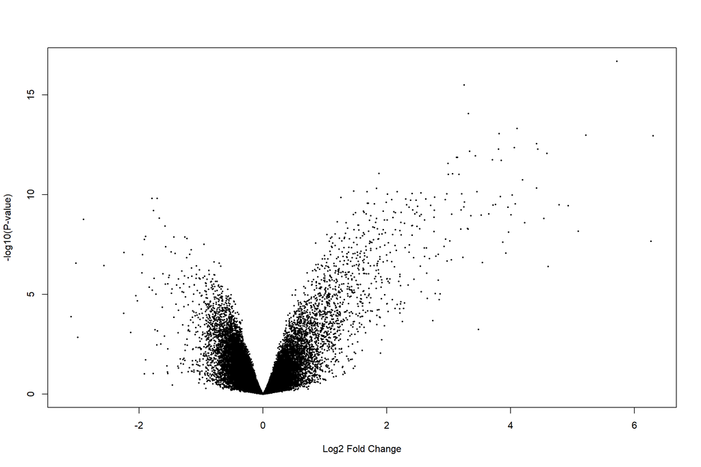

```r
volcanoplot(fit2)
```

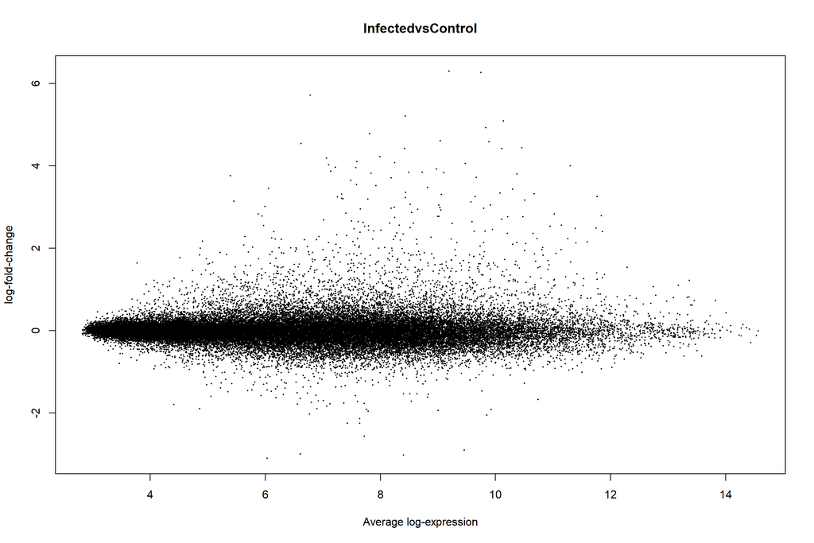

```r
limma::plotMA(fit2)
```

```r
# DE results
LIMMAout <- topTable(fit2,adjust="BH",number=nrow(exprs(miceRMA)))
#head(LIMMAout)

## Check intensity values for top results
exprs(miceRMA)[rownames(exprs(miceRMA))%in%rownames(head(LIMMAout)),]
```

```
##              GSM1579245_jac013-430v2.CEL GSM1579246_jac021-430v2.CEL
## 1418293_at                      8.850220                    8.697405
## 1419697_at                      4.873087                    5.196294
## 1424518_at                      5.610642                    5.255470
## 1449025_at                      9.824438                    9.841855
## 1450297_at                      3.450449                    3.409701
## 1451905_a_at                    5.271445                    5.483409
##              GSM1579247_jac044-430v2.CEL GSM1579248_jac045-430v2.CEL
## 1418293_at                      8.628802                    8.583339
## 1419697_at                      4.944273                    4.957930
## 1424518_at                      5.033368                    5.491428
## 1449025_at                      9.930787                    9.733168
## 1450297_at                      3.628502                    3.614535
## 1451905_a_at                    5.814011                    5.916976
##              GSM1579249_jac046-430v2.CEL GSM1579250_jac007-430v2.CEL
## 1418293_at                      8.979707                   13.280513
## 1419697_at                      5.156156                   12.484048
## 1424518_at                      5.391127                    9.926284
## 1449025_at                     10.059654                   13.751370
## 1450297_at                      3.661825                   10.544846
## 1451905_a_at                    6.290288                   12.039855
##              GSM1579251_jac008-430v2.CEL GSM1579252_jac036-430v2.CEL
## 1418293_at                      13.17569                    13.17675
## 1419697_at                      12.58070                    12.54747
## 1424518_at                      10.07358                    10.38063
## 1449025_at                      13.69643                    13.85968
## 1450297_at                      10.77543                    10.84424
## 1451905_a_at                    11.65031                    12.11285
##              GSM1579253_jac047-430v2.CEL GSM1579254_jac014-430v2.CEL
## 1418293_at                      13.07904                    8.738460
## 1419697_at                      12.59532                    4.815025
## 1424518_at                      10.27056                    5.208682
## 1449025_at                      13.77391                   10.119994
## 1450297_at                      10.40172                    3.770888
## 1451905_a_at                    11.95163                    5.430919
##              GSM1579255_jac024-430v2.CEL GSM1579256_jac025-430v2.CEL
## 1418293_at                      8.723118                    8.699255
## 1419697_at                      5.156243                    4.948877
## 1424518_at                      5.235854                    5.688553
## 1449025_at                     10.063244                   10.129423
## 1450297_at                      3.496160                    3.556766
## 1451905_a_at                    5.635768                    5.014256
##              GSM1579257_jac011-430v2.CEL GSM1579258_jac012-430v2.CEL
## 1418293_at                     12.021105                   12.276407
## 1419697_at                      8.623987                    9.287277
## 1424518_at                      9.305259                    9.485391
## 1449025_at                     13.289408                   13.458878
## 1450297_at                      9.421028                    9.491732
## 1451905_a_at                   10.501785                   10.709535
##              GSM1579259_jac037-430v2.CEL GSM1579260_jac048-430v2.CEL
## 1418293_at                     11.864963                   11.991672
## 1419697_at                      8.614776                    8.632264
## 1424518_at                      9.530186                    9.606000
## 1449025_at                     13.312026                   13.363678
## 1450297_at                      9.073683                    9.311915
## 1451905_a_at                   10.413056                   10.672276
```

```r
#mean expression of control/DBA2J
rowMeans(exprs(miceRMA)[rownames(exprs(miceRMA))%in%rownames(head(LIMMAout)),1:5])
```

```
##   1418293_at   1419697_at   1424518_at   1449025_at   1450297_at 1451905_a_at
##     8.747894     5.025548     5.356407     9.877981     3.553002     5.755226
```

```r
#mean expression of infected/DBA2J
rowMeans(exprs(miceRMA)[rownames(exprs(miceRMA))%in%rownames(head(LIMMAout)),6:9])
```

```
##   1418293_at   1419697_at   1424518_at   1449025_at   1450297_at 1451905_a_at
##     13.17800     12.55189     10.16277     13.77035     10.64156     11.93866
```

```r
#mean expression of control/C57BL6
rowMeans(exprs(miceRMA)[rownames(exprs(miceRMA))%in%rownames(head(LIMMAout)),10:12])
```

```
##   1418293_at   1419697_at   1424518_at   1449025_at   1450297_at 1451905_a_at
##     8.720277     4.973382     5.377696    10.104220     3.607938     5.360314
```

```r
#mean expression of infected/C57BL6
rowMeans(exprs(miceRMA)[rownames(exprs(miceRMA))%in%rownames(head(LIMMAout)),13:16])
```

```
##   1418293_at   1419697_at   1424518_at   1449025_at   1450297_at 1451905_a_at
##    12.038537     8.789576     9.481709    13.355997     9.324589    10.574163
```

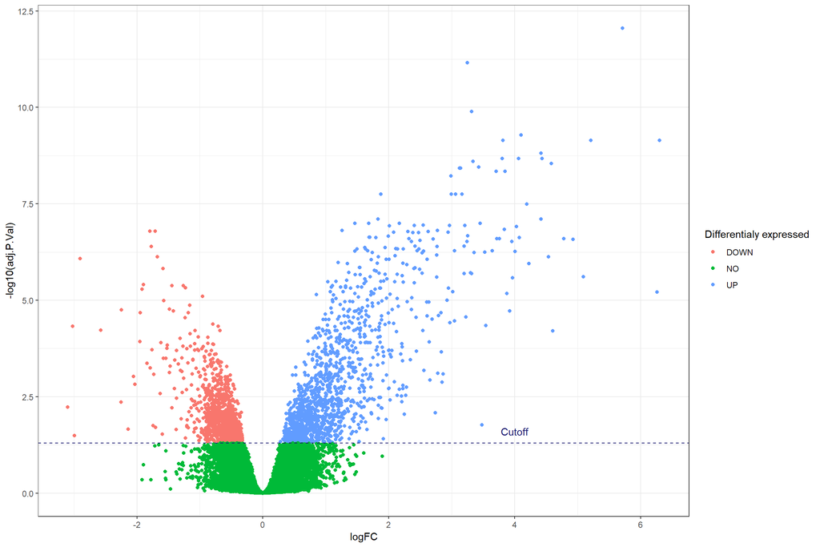

```r
#Adjustments on p values using Benjamini-Hochberg
LIMMAout$diffexpressed <- "NO"
LIMMAout$diffexpressed[LIMMAout$logFC > 0 & LIMMAout$adj.P.Val < 0.05] <- "UP"
LIMMAout$diffexpressed[LIMMAout$logFC < 0 & LIMMAout$adj.P.Val < 0.05] <- "DOWN"

#No adjustments on pvalues
LIMMAout$diffexpressed_no_BH <- "NO"
LIMMAout$diffexpressed_no_BH[LIMMAout$logFC > 0 & LIMMAout$P.Value < 0.05] <- "UP"
LIMMAout$diffexpressed_no_BH[LIMMAout$logFC < 0 & LIMMAout$P.Value < 0.05] <- "DOWN"

C57_down <- LIMMAout[LIMMAout$diffexpressed_no_BH=="DOWN", ]
C57_up <- LIMMAout[LIMMAout$diffexpressed_no_BH=="UP", ]

a <- subset(LIMMAout, LIMMAout$diffexpressed_no_BH=="DOWN")

ggplot(data = LIMMAout, aes(x= logFC, y = -log10(adj.P.Val), colour = diffexpressed)) +
 geom_point()+
 theme_bw()+
  geom_hline(yintercept = -log10(0.05), linetype="dashed", color="midnightblue")+
  annotate("text", min(4), 1.3, vjust = -1, label = "Cutoff", color="midnightblue")+
 #ggtitle("Differentiall (unadjusted P-value)") +
 labs(colour = "Differentialy expressed")
```

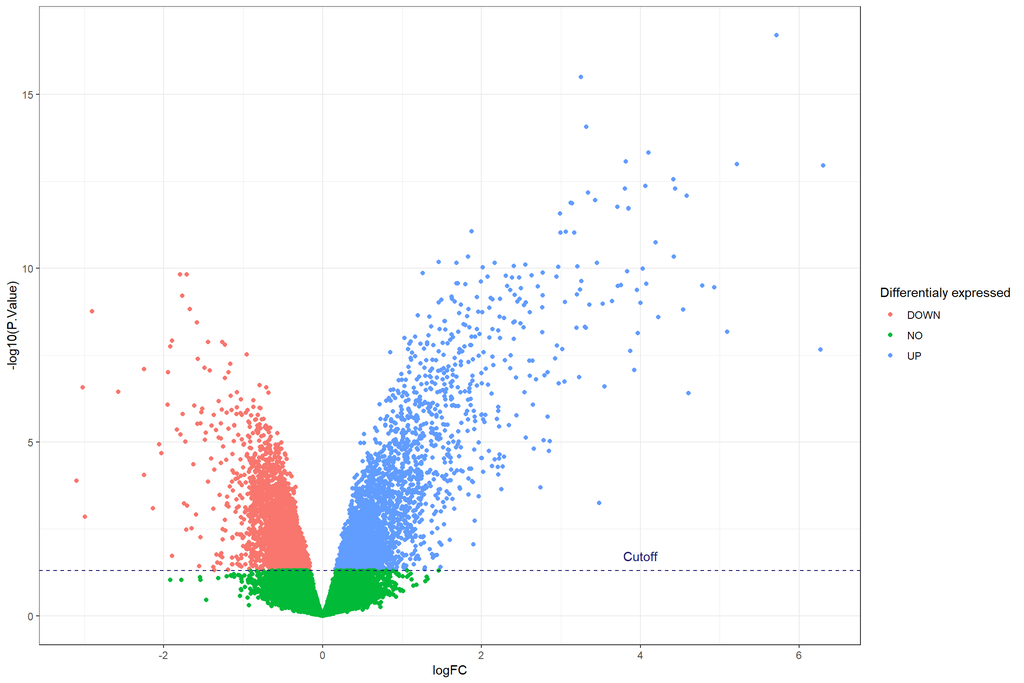

```r
 #theme(plot.title = element_text(hjust = 0.5, face = "bold.italic"))

ggplot(data = LIMMAout, aes(x= logFC, y = -log10(P.Value), colour = diffexpressed_no_BH)) +
 geom_point()+
 theme_bw()+
  geom_hline(yintercept = -log10(0.05), linetype="dashed", color="midnightblue")+
  annotate("text", min(4), 1.3, vjust = -1, label = "Cutoff", color="midnightblue")+
 #ggtitle("Differentiall (unadjusted P-value)") +
 labs(colour = "Differentialy expressed")
```

```r
length(which(LIMMAout$diffexpressed=="UP"))
```

```
## [1] 1324
```

```r
length(which(LIMMAout$diffexpressed=="DOWN"))
```

```
## [1] 1039
```

```r
length(which(LIMMAout$diffexpressed_no_BH=="UP"))
```

```
## [1] 3114
```

```r
length(which(LIMMAout$diffexpressed_no_BH=="DOWN"))
```

```
## [1] 3867
```

```r
## Load annotation and sort alphabetically on probe name
annotation_MA <- read.table("C:/Users/tobia/Downloads/Array2/A-AFFY-45.adf.txt",header=T,sep="\t",skip=17,fill=T)
print(head(annotation_MA))
```

```
##   Composite.Element.Name Composite.Element.Database.Entry.interpro.
## 1         AFFX-BioB-5_at                                  IPR007197
## 2         AFFX-BioB-M_at                                  IPR007197
## 3         AFFX-BioB-3_at                                  IPR007197
## 4         AFFX-BioC-5_at
## 5         AFFX-BioC-3_at
## 6        AFFX-BioDn-5_at                                  IPR002586
##   Composite.Element.Database.Entry.embl.
## 1                            AFFX-BioB-5
## 2                            AFFX-BioB-M
## 3                            AFFX-BioB-3
## 4                            AFFX-BioC-5
## 5                            AFFX-BioC-3
## 6                           AFFX-BioDn-5
##   Composite.Element.Database.Entry.affymetrix_netaffx.
## 1                                       AFFX-BioB-5_at
## 2                                       AFFX-BioB-M_at
## 3                                       AFFX-BioB-3_at
## 4                                       AFFX-BioC-5_at
## 5                                       AFFX-BioC-3_at
## 6                                      AFFX-BioDn-5_at
##   Composite.Element.Database.Entry.genbank.
## 1
## 2
## 3
## 4
## 5
## 6                                 NP_752788
##   Composite.Element.Database.Entry.ec. Composite.Element.Database.Entry.refseq.
## 1
## 2
## 3
## 4
## 5
## 6
##   Composite.Element.Database.Entry.swall.
## 1
## 2
## 3
## 4
```

[output cut: 36 more lines]

```
## 6
##   Composite.Element.Database.Entry.scop.
## 1
## 2
## 3
## 4
## 5
## 6
##   Composite.Element.Database.Entry.cp450.
## 1
## 2
## 3
## 4
## 5
## 6
```

```r
annotation_MA <- annotation_MA[sort(annotation_MA$Composite.Element.Name,index.return=T)$ix,]

## Check if all probes are present in both sets
dim(annotation_MA)
```

```
## [1] 45101    16
```

```r
dim(LIMMAout)
```

```
## [1] 45101     8
```

```r
## Double check => "Assumption is the mother of all fuck up's ;)"
sum(annotation_MA$Composite.Element.Name==sort(rownames(LIMMAout)))
```

```
## [1] 45101
```

```r
## Sort LIMMA output alphabetically on probe name
LIMMAout_sorted <- LIMMAout[sort(rownames(LIMMAout),index.return=T)$ix,]
#LIMMAout_sorted

## Add gene names to LIMMA output
LIMMAout_sorted$gene <- annotation_MA$Composite.Element.Database.Entry.ensembl.
LIMMAout_annot <- LIMMAout_sorted[sort(LIMMAout_sorted$adj.P.Val,index.return=T)$ix,]

#sort by adjusted p value from most significant to least
LIMMAout_sorted2 <- LIMMAout_sorted[order(LIMMAout_sorted$adj.P.Val, decreasing= F),]

#extract top 50 significant DE genes
LIMMAout_sorted2[1:50,]$gene
```

```
##  [1] "ENSMUSG00000025746" "ENSMUSG00000045303" "ENSMUSG00000045932"
##  [4] "ENSMUSG00000051925" "ENSMUSG00000034855" "ENSMUSG00000029419"
##  [7] "ENSMUSG00000023341" "ENSMUSG00000041827" "ENSMUSG00000022548"
## [10] ""                   "ENSMUSG00000047610" "ENSMUSG00000054261"
## [13] ""                   "ENSMUSG00000030107" "ENSMUSG00000025165"
## [16] "ENSMUSG00000020638" "ENSMUSG00000015947" "ENSMUSG00000022586"
## [19] "ENSMUSG00000027514" ""                   "ENSMUSG00000035152"
## [22] "ENSMUSG00000017830" "ENSMUSG00000029561" ""
## [25] "ENSMUSG00000048806" "ENSMUSG00000025498" "ENSMUSG00000035208"
## [28] "ENSMUSG00000022906" "ENSMUSG00000029379" ""
## [31] "ENSMUSG00000010358" "ENSMUSG00000039364" "ENSMUSG00000046031"
## [34] ""                   "ENSMUSG00000030921" "ENSMUSG00000019910"
## [37] ""                   "ENSMUSG00000001131" ""
## [40] "ENSMUSG00000003617" "ENSMUSG00000009670" "ENSMUSG00000028957"
## [43] "ENSMUSG00000023341" "ENSMUSG00000055116" "ENSMUSG00000015947"
## [46] ""                   ""                   ""
## [49] "ENSMUSG00000024371" ""
```

```r
# Have a look at the results and search for other probesets for your DE genes
head(LIMMAout_annot)
```

```
##               logFC   AveExpr        t      P.Value    adj.P.Val        B
## 1450297_at 5.716651  6.778338 44.60100 1.977975e-17 8.920867e-13 25.91879
## 1449025_at 3.251777 11.762997 37.08774 3.118352e-16 7.032040e-12 24.48160
## 1418293_at 3.318259 10.672902 29.69841 8.518266e-15 1.280608e-10 22.40893
## 1424518_at 4.104013  7.593314 26.49470 4.619705e-14 5.208833e-10 21.21036
## 1418930_at 6.303782  9.190682 24.97055 1.107804e-13 7.137579e-10 20.55617
## 1419697_at 3.816194  7.838359 25.43495 8.441607e-14 7.137579e-10 20.76185
##            diffexpressed diffexpressed_no_BH               gene
## 1450297_at            UP                  UP ENSMUSG00000025746
## 1449025_at            UP                  UP ENSMUSG00000045303
## 1418293_at            UP                  UP ENSMUSG00000045932
## 1424518_at            UP                  UP ENSMUSG00000051925
## 1418930_at            UP                  UP ENSMUSG00000034855
## 1419697_at            UP                  UP ENSMUSG00000029419
```

```r
LIMMAout_annot[LIMMAout_annot$gene=="   ENSMUSG00000022548",]
```

```
## [1] logFC               AveExpr             t
## [4] P.Value             adj.P.Val           B
## [7] diffexpressed       diffexpressed_no_BH gene
## <0 rows> (or 0-length row.names)
```

```r
#extract DE genes
DEgenes <- LIMMAout_sorted2$gene[LIMMAout_sorted2$adj.P.Val <= 0.05]
DEgenes <- DEgenes[DEgenes != ""]

head(DEgenes)
```

```
## [1] "ENSMUSG00000025746" "ENSMUSG00000045303" "ENSMUSG00000045932"
## [4] "ENSMUSG00000051925" "ENSMUSG00000034855" "ENSMUSG00000029419"
```